# TMDb电影数据分析

研究目的：本文通过对电影数据库TMDb的1万条从1968～2015年电影数据的清理和分析，探讨二十世纪以来电影产业的发展规律，  
并进一步探究何种特征的电影会对票房收益和用户评价产生积极影响，以期为电影产业的发展留下一些思考和结论。

分析思路：

一，数据数据读取/评估和清理 1，数据结构 2，异常值处理

二，数据分析  
PART 1：电影产业规律分析

1，票房收益角度，选取字段调整后的收入(revenue_adj) - 调整后的预算(budget_adj)，得到调整后的收益(profit_adj)；  
2，用户评价角度，选取查看次数popularity和平均评分vote_average字段；

回答以下问题：

```
Q1，整体电影产业收益是否在增长，年总票房盈利的变化？
Q2，各电影公司每年盈利是否在增长，年均票房盈利的变化？
Q3，大众对电影的关注是否呈现逐年增加的趋势？
Q4，随着电影技术的发展，当前发行电影的评分是否也在增加？
Q5，占领市场最多的影片类型/电影公司/导演和演员？
```

PART 2：评价角度的选取

1，从票房收益和用户评价两个角度来进行电影评价；  
2，考虑选取字段自身的影响因素和相互间的关系，从而确定评价电影的因变量；

回答以下问题

```
Q1，相对网页查看次数popularity和平均评分vote_average之间的相关性，是否查看多的影片评分就高？
Q2，分析用户评价（包括查看次数和平均评分）和票房收益之间的相关性，从而确定评价电影的指标为何？
```

PART 3：影响电影收益和评价的因素分析

考虑什么特征的电影会票房收益高/用户评价好，回答以下问题：

```
Q1，电影时长runtime分析，主要时长是多少分钟，是否对票房收益和电影评价有影响？
Q2，电影发行月份分析，主要发行月份集中在哪个月，是否对票房收益和电影评价有影响？
```

三，结论  
1，研究问题总结  
1）20世纪电影产业发展规律  
2）电影收益和评价影响因素及策略

2，不足与展望

## 一，数据读取/评估和清理

### 1，数据结构

```python
#读取 CSV 文件，head()查看基本数据结构
import pandas as pd
df = pd.read_csv('tmdb-movies.csv')
df.head()
```

|  | id | imdb_id | popularity | budget | revenue | original_title | cast | homepage | director | tagline | ... | overview | runtime | genres | production_companies | release_date | vote_count | vote_average | release_year | budget_adj | revenue_adj |
| --- | --- | --- | --- | --- | --- | --- | --- | --- | --- | --- | --- | --- | --- | --- | --- | --- | --- | --- | --- | --- | --- |
| 0 | 135397 | tt0369610 | 32.985763 | 150000000 | 1513528810 | Jurassic World | Chris Pratt\|Bryce Dallas Howard\|Irrfan Khan\|Vi... | http://www.jurassicworld.com/ | Colin Trevorrow | The park is open. | ... | Twenty-two years after the events of Jurassic ... | 124 | Action\|Adventure\|Science Fiction\|Thriller | Universal Studios\|Amblin Entertainment\|Legenda... | 6/9/15 | 5562 | 6.5 | 2015 | 1.379999e+08 | 1.392446e+09 |
| 1 | 76341 | tt1392190 | 28.419936 | 150000000 | 378436354 | Mad Max: Fury Road | Tom Hardy\|Charlize Theron\|Hugh Keays-Byrne\|Nic... | http://www.madmaxmovie.com/ | George Miller | What a Lovely Day. | ... | An apocalyptic story set in the furthest reach... | 120 | Action\|Adventure\|Science Fiction\|Thriller | Village Roadshow Pictures\|Kennedy Miller Produ... | 5/13/15 | 6185 | 7.1 | 2015 | 1.379999e+08 | 3.481613e+08 |
| 2 | 262500 | tt2908446 | 13.112507 | 110000000 | 295238201 | Insurgent | Shailene Woodley\|Theo James\|Kate Winslet\|Ansel... | http://www.thedivergentseries.movie/#insurgent | Robert Schwentke | One Choice Can Destroy You | ... | Beatrice Prior must confront her inner demons ... | 119 | Adventure\|Science Fiction\|Thriller | Summit Entertainment\|Mandeville Films\|Red Wago... | 3/18/15 | 2480 | 6.3 | 2015 | 1.012000e+08 | 2.716190e+08 |
| 3 | 140607 | tt2488496 | 11.173104 | 200000000 | 2068178225 | Star Wars: The Force Awakens | Harrison Ford\|Mark Hamill\|Carrie Fisher\|Adam D... | http://www.starwars.com/films/star-wars-episod... | J.J. Abrams | Every generation has a story. | ... | Thirty years after defeating the Galactic Empi... | 136 | Action\|Adventure\|Science Fiction\|Fantasy | Lucasfilm\|Truenorth Productions\|Bad Robot | 12/15/15 | 5292 | 7.5 | 2015 | 1.839999e+08 | 1.902723e+09 |
| 4 | 168259 | tt2820852 | 9.335014 | 190000000 | 1506249360 | Furious 7 | Vin Diesel\|Paul Walker\|Jason Statham\|Michelle ... | http://www.furious7.com/ | James Wan | Vengeance Hits Home | ... | Deckard Shaw seeks revenge against Dominic Tor... | 137 | Action\|Crime\|Thriller | Universal Pictures\|Original Film\|Media Rights ... | 4/1/15 | 2947 | 7.3 | 2015 | 1.747999e+08 | 1.385749e+09 |

5 rows × 21 columns

数据包含每个部影片的影片信息（片名/类型/主页/导演/演员/出版年份/时长/公司等）以及评价信息（预算/收入/网页查看次数/平分次数/平均评分等）两大板块； 分析时数据字段需要处理的可能会有： 1，分析演员与影片评价之间关系时，需要对cast字段做处理，提取出各演员名； 2，同理分析影片类型/影片公司和发布月份与影片评价间关系时，也需要对genres/production_companies和release_date字段做提取处理。

```python
#每个数据集中的列数
df.shape
```

```
(10866, 21)
```

```python
#列的数据类型
df.dtypes
```

```
id                        int64
imdb_id                  object
popularity              float64
budget                    int64
revenue                   int64
original_title           object
cast                     object
homepage                 object
director                 object
tagline                  object
keywords                 object
overview                 object
runtime                   int64
genres                   object
production_companies     object
release_date             object
vote_count                int64
vote_average            float64
release_year              int64
budget_adj              float64
revenue_adj             float64
dtype: object
```

### 异常值处理

```python
# 丢弃分析不需要的列
df.drop(['id', 'imdb_id', 'homepage', 'tagline', 'overview', 'keywords'], axis=1, inplace=True)
# 确认更改
df.head(1)
```

|  | popularity | budget | revenue | original_title | cast | director | runtime | genres | production_companies | release_date | vote_count | vote_average | release_year | budget_adj | revenue_adj |
| --- | --- | --- | --- | --- | --- | --- | --- | --- | --- | --- | --- | --- | --- | --- | --- |
| 0 | 32.985763 | 150000000 | 1513528810 | Jurassic World | Chris Pratt\|Bryce Dallas Howard\|Irrfan Khan\|Vi... | Colin Trevorrow | 124 | Action\|Adventure\|Science Fiction\|Thriller | Universal Studios\|Amblin Entertainment\|Legenda... | 6/9/15 | 5562 | 6.5 | 2015 | 1.379999e+08 | 1.392446e+09 |

```python
# 用 info() 检查哪些列有缺失值
df.info()
```

```
<class 'pandas.core.frame.DataFrame'>
RangeIndex: 10866 entries, 0 to 10865
Data columns (total 15 columns):
popularity              10866 non-null float64
budget                  10866 non-null int64
revenue                 10866 non-null int64
original_title          10866 non-null object
cast                    10790 non-null object
director                10822 non-null object
runtime                 10866 non-null int64
genres                  10843 non-null object
production_companies    9836 non-null object
release_date            10866 non-null object
vote_count              10866 non-null int64
vote_average            10866 non-null float64
release_year            10866 non-null int64
budget_adj              10866 non-null float64
revenue_adj             10866 non-null float64
dtypes: float64(4), int64(5), object(6)
memory usage: 1.2+ MB
```

```python
df.isnull().sum()
```

```
popularity                 0
budget                     0
revenue                    0
original_title             0
cast                      76
director                  44
runtime                    0
genres                    23
production_companies    1030
release_date               0
vote_count                 0
vote_average               0
release_year               0
budget_adj                 0
revenue_adj                0
dtype: int64
```

```python
#丢弃数据集中有任何空值的行
df.dropna(inplace=True)
#丢弃空值后剩余的数据数量
df.shape
```

```
(9773, 15)
```

```python
# 检查数据中的重复
df.duplicated().sum()
```

```
1
```

```python
# 丢弃重复
df.drop_duplicates(inplace = True)
```

```python
# 再次检查数据中的重复，确认修改
df.duplicated().sum()
```

```
0
```

```python
#变更release_date的字段格式
df['release_date'] = pd.to_datetime(df['release_date'])
df['release_date_year'] = df['release_date'].dt.year
df['release_date_year'].unique()
```

```
array([2015, 2014, 1977, 2009, 2010, 1999, 2001, 2008, 2011, 2002, 1994,
       2012, 2003, 1997, 2013, 1985, 2005, 2006, 2004, 1972, 1980, 2007,
       1979, 1984, 1983, 1995, 1992, 1981, 1996, 2000, 1982, 1998, 1989,
       1991, 1988, 1987, 1968, 1974, 1975, 2062, 2064, 1971, 1990, 2061,
       2060, 1976, 1993, 2067, 2063, 1986, 1973, 1970, 2065, 1969, 1978,
       2066])
```

```python
# 过滤年份小于或等于2018的行的数据集
df = df.query('release_date_year <= 2018')
df['release_date_year'].unique()
```

```
array([2015, 2014, 1977, 2009, 2010, 1999, 2001, 2008, 2011, 2002, 1994,
       2012, 2003, 1997, 2013, 1985, 2005, 2006, 2004, 1972, 1980, 2007,
       1979, 1984, 1983, 1995, 1992, 1981, 1996, 2000, 1982, 1998, 1989,
       1991, 1988, 1987, 1968, 1974, 1975, 1971, 1990, 1976, 1993, 1986,
       1973, 1970, 1969, 1978])
```

```python
df.describe()
```

|  | popularity | budget | revenue | runtime | vote_count | vote_average | release_year | budget_adj | revenue_adj | release_date_year |
| --- | --- | --- | --- | --- | --- | --- | --- | --- | --- | --- |
| count | 9491.000000 | 9.491000e+03 | 9.491000e+03 | 9491.000000 | 9491.000000 | 9491.000000 | 9491.000000 | 9.491000e+03 | 9.491000e+03 | 9491.000000 |
| mean | 0.702660 | 1.660980e+07 | 4.527658e+07 | 102.599305 | 244.346960 | 5.954325 | 2001.978927 | 1.965117e+07 | 5.691097e+07 | 2001.978927 |
| std | 1.047369 | 3.257791e+07 | 1.241414e+08 | 27.718457 | 610.595317 | 0.915264 | 11.520275 | 3.583186e+07 | 1.498976e+08 | 11.520275 |
| min | 0.000188 | 0.000000e+00 | 0.000000e+00 | 0.000000 | 10.000000 | 1.500000 | 1968.000000 | 0.000000e+00 | 0.000000e+00 | 1968.000000 |
| 25% | 0.237140 | 0.000000e+00 | 0.000000e+00 | 90.000000 | 19.000000 | 5.400000 | 1995.000000 | 0.000000e+00 | 0.000000e+00 | 1995.000000 |
| 50% | 0.424196 | 4.500000e+05 | 0.000000e+00 | 99.000000 | 47.000000 | 6.000000 | 2006.000000 | 5.500000e+05 | 0.000000e+00 | 2006.000000 |
| 75% | 0.785720 | 2.000000e+07 | 3.247840e+07 | 112.000000 | 179.000000 | 6.600000 | 2011.000000 | 2.531967e+07 | 4.368141e+07 | 2011.000000 |
| max | 32.985763 | 4.250000e+08 | 2.781506e+09 | 877.000000 | 9767.000000 | 8.700000 | 2015.000000 | 4.250000e+08 | 2.827124e+09 | 2015.000000 |

```python
#删除budget、runtime中存在0时长，并且有部分特征25%的数据都是0值等异常值
df = df[(df.budget>0) & (df.revenue>0) & (df.runtime>0) & (df.budget_adj>0) & (df.revenue_adj>0)]
#再次检查数据
df.describe()
```

|  | popularity | budget | revenue | runtime | vote_count | vote_average | release_year | budget_adj | revenue_adj | release_date_year |
| --- | --- | --- | --- | --- | --- | --- | --- | --- | --- | --- |
| count | 3747.000000 | 3.747000e+03 | 3.747000e+03 | 3747.000000 | 3747.000000 | 3747.000000 | 3747.000000 | 3.747000e+03 | 3.747000e+03 | 3747.000000 |
| mean | 1.207226 | 3.808858e+07 | 1.100056e+08 | 108.967441 | 538.914598 | 6.160742 | 2001.809714 | 4.470707e+07 | 1.363282e+08 | 2001.809714 |
| std | 1.488140 | 4.246273e+07 | 1.783605e+08 | 19.276614 | 889.101475 | 0.790276 | 10.399050 | 4.489952e+07 | 2.135130e+08 | 10.399050 |
| min | 0.010335 | 1.000000e+00 | 2.000000e+00 | 15.000000 | 10.000000 | 2.200000 | 1968.000000 | 9.693980e-01 | 2.370705e+00 | 1968.000000 |
| 25% | 0.471573 | 1.000000e+07 | 1.456596e+07 | 96.000000 | 75.000000 | 5.700000 | 1996.000000 | 1.337695e+07 | 1.890566e+07 | 1996.000000 |
| 50% | 0.813396 | 2.500000e+07 | 4.666586e+07 | 105.000000 | 212.000000 | 6.200000 | 2004.000000 | 3.039182e+07 | 6.203273e+07 | 2004.000000 |
| 75% | 1.387598 | 5.000000e+07 | 1.279725e+08 | 119.000000 | 589.000000 | 6.700000 | 2010.000000 | 6.091278e+07 | 1.630210e+08 | 2010.000000 |
| max | 32.985763 | 4.250000e+08 | 2.781506e+09 | 338.000000 | 9767.000000 | 8.400000 | 2015.000000 | 4.250000e+08 | 2.827124e+09 | 2015.000000 |

```python
df.shape
```

```
(3747, 16)
```

## PART 1：电影产业规律分析

```python
import matplotlib.pyplot as plt
%matplotlib inline
import seaborn as sns
df['profit_adj'] = df.revenue_adj - df.budget_adj
df.head(1)
```

|  | popularity | budget | revenue | original_title | cast | director | runtime | genres | production_companies | release_date | vote_count | vote_average | release_year | budget_adj | revenue_adj | release_date_year | profit_adj |
| --- | --- | --- | --- | --- | --- | --- | --- | --- | --- | --- | --- | --- | --- | --- | --- | --- | --- |
| 0 | 32.985763 | 150000000 | 1513528810 | Jurassic World | Chris Pratt\|Bryce Dallas Howard\|Irrfan Khan\|Vi... | Colin Trevorrow | 124 | Action\|Adventure\|Science Fiction\|Thriller | Universal Studios\|Amblin Entertainment\|Legenda... | 2015-06-09 | 5562 | 6.5 | 2015 | 1.379999e+08 | 1.392446e+09 | 2015 | 1.254446e+09 |

```python
profit_adj_totyear = df.groupby('release_date_year').sum()['profit_adj']
profit_adj_avgyear = df.groupby('release_date_year').mean()['profit_adj']
popularity_avgyear = df.groupby('release_date_year').mean()['popularity']
vote_average_avgyear = df.groupby('release_date_year').mean()['vote_average']
```

### Q1，整体电影产业收益是否在增长，年总票房盈利的变化？

### Q2，各电影公司每年盈利是否在增长，年均票房盈利的变化？

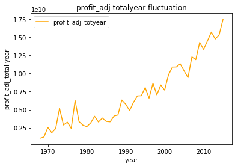

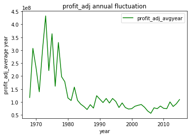

```python
# 比较年份变化下票房和评价的变化情况
plt.title('profit_adj totalyear fluctuation')
plt.plot(profit_adj_totyear, color='orange', label='profit_adj_totyear')
plt.legend()
plt.xlabel('year')
plt.ylabel('profit_adj_total year')
plt.show()
plt.title('profit_adj annual fluctuation')
plt.plot(profit_adj_avgyear, color='green', label='profit_adj_avgyear')
plt.legend()
plt.xlabel('year')
plt.ylabel('profit_adj_average year')
plt.show()
```

结论：随着年份的增长，电影的票房调整后数据虽然年收益整体是增长的，但平均到每部片的年均盈利是下降的

### Q3，大众对电影的关注是否呈现逐年增加的趋势？

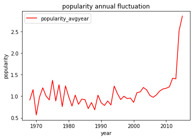

```python
plt.title('popularity annual fluctuation')
plt.plot(popularity_avgyear, color='red', label='popularity_avgyear')
plt.legend()
plt.xlabel('year')
plt.ylabel('popularity')
plt.show()
```

结论：随着年份的增长，大众对电影的关注是增加的

### Q4，随着电影技术的发展，当前发行电影的评分是否也在增加？

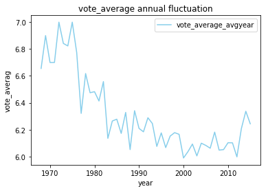

```python
plt.title('vote_average annual fluctuation')
plt.plot(vote_average_avgyear, color='skyblue', label='vote_average_avgyear')
plt.legend()
plt.xlabel('year')
plt.ylabel('vote_averag')
plt.show()
```

结论：随着年份的增长，观众对当前发行电影的评分是下降的

### Q5，占领市场最多的影片类型/电影公司/导演和演员？

```python
# 分隔影片类型/电影公司/导演和演员等列
def extract_data(column_name):
    all_data = df[column_name].str.cat(sep = '|')
    all_data = pd.Series(all_data.split('|'))
    count = all_data.value_counts(ascending = False)
    return count
```

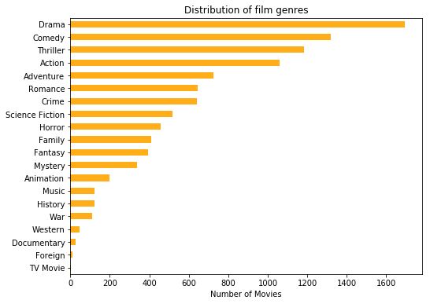

```
TV Movie         1
Foreign          9
Documentary     26
Western         47
War            112
dtype: int64
```

```python
#1，影片类型分析
genre_count = extract_data('genres')

#规律，哪种电影类型发部的电影数量多
genre_count.sort_values(ascending = True, inplace = True)
ax = genre_count.plot.barh( color = 'orange', fontsize = 10, alpha = 0.9)
ax.set(title = 'Distribution of film genres')
ax.set_xlabel('Number of Movies', color = 'black', fontsize = '10')
ax.figure.set_size_inches(8, 6)
plt.show()
print(genre_count.head())
```

```python
#2，电影公司分析
#规律，哪些电影公司发部的电影数量多/盈利高/口碑好
production_companies_count = extract_data('production_companies')
production_companies_count.head()
```

```
Universal Pictures                        324
Warner Bros.                              321
Paramount Pictures                        267
Twentieth Century Fox Film Corporation    197
Columbia Pictures                         177
dtype: int64
```

```python
#3，导演分析
#规律，哪些导演发布的电影多
director_count = extract_data('director')
director_count.head()
```

```
Steven Spielberg    28
Clint Eastwood      24
Ridley Scott        21
Woody Allen         18
Martin Scorsese     17
dtype: int64
```

```python
#4，演员分析
#规律，哪些导演发布的电影多
cast_count = extract_data('cast')
cast_count.head()
```

```
Robert De Niro       52
Bruce Willis         46
Samuel L. Jackson    44
Nicolas Cage         43
Matt Damon           36
dtype: int64
```

## PART 2：评价角度的选取

### Q1，相对网页查看次数popularity和平均评分vote_average之间的相关性，是否查看多的影片评分就高？

```
Text(0.5,1,'Point diagram of vote_average and movie popularity')
```

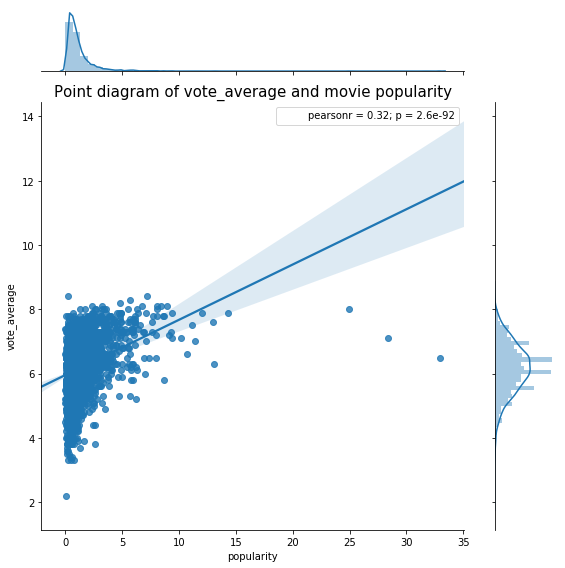

```python
# 描述查看次数和平均评分之间的相关性
df1 = df[['popularity', 'vote_average', 'profit_adj']]
sns.jointplot(data=df1, y='vote_average', x='popularity', kind="reg", size=8, space=0.5)
plt.title('Point diagram of vote_average and movie popularity',fontsize=15)
```

结论：相对网页查看次数popularity与平均评分vote_average间基本正相关；

### Q2，分析用户评价（包括查看次数和平均评分）和票房收益之间的相关性，从而确定评价电影的指标为何？

```
Text(0.5,1,'Point diagram of box office and movie popularity')
```

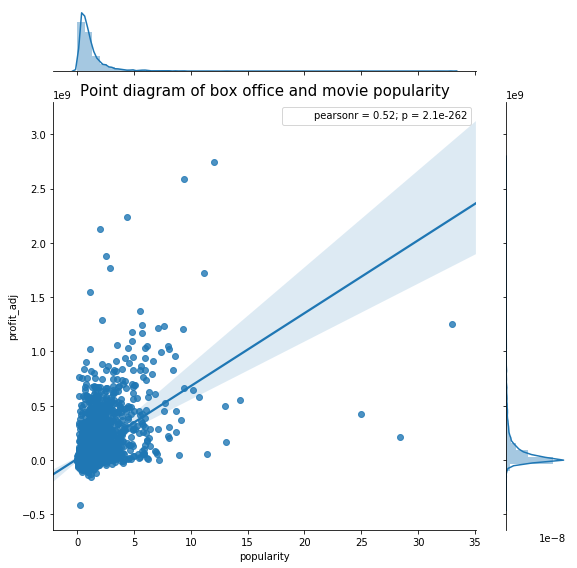

```python
# 描述网页查看次数和票房收益之间的相关性
sns.jointplot(data=df1, y='profit_adj', x='popularity', kind="reg", size=8, space=0.5)
plt.title('Point diagram of box office and movie popularity',fontsize=15)
```

```
Text(0.5,1,'Point diagram of box office and movie score')
```

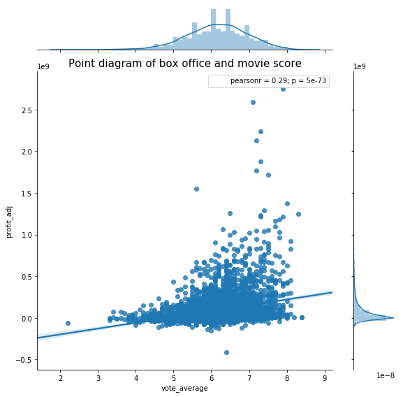

```python
# 描述观众平均评分和票房收益之间的相关性
sns.jointplot(data=df1, y='profit_adj', x='vote_average', kind="reg", size=8, space=0.5)
plt.title('Point diagram of box office and movie score',fontsize=15)
```